# Casual-to-Member Conversion Strategy

## Contents

1. Business Question
2. Data & Preparation
3. Casual vs. Member: First Look
4. Segmentation into Subgroups
5. Subgroup Profiles
   - Are Members Homogeneous?
   - All Subgroups at a Glance
6. Similarity, Volume & Conversion Priority
   - 6.1 Similarity to Member Behaviour
   - 6.2 Ride Volume by Subgroup
   - 6.3 Conversion Priority
   - E-Bike Usage Among PM Casual Commuters
7. Per-Subgroup Breakdown
8. Conclusions & Recommendations
9. Limitations

## 1 · Business Question

Cyclistic is a Chicago bike-share service with two user types: **casual riders** (single ride or day pass) and **annual members** (flat-rate subscription). The marketing team's hypothesis is that converting high-potential casual riders into annual members is the most cost-effective growth lever.

Three questions drive this analysis:

1. How do casual riders actually behave differently from annual members?
2. Are casual riders one uniform group, or do distinct behavioural profiles exist within them?
3. Which profiles are structurally closest to member behaviour — and large enough to be worth targeting?

> **Note:** segmentation is at ride level, not customer level. No persistent user ID is available, so clusters describe patterns of behaviour, not individual people.

↑ back to top

## 2 · Data & Preparation

The raw data is one row per ride — timestamps, GPS coordinates, bike type, user type. Before the analysis, I derive a set of behavioural features from the raw fields.

| Feature | Description |
| --- | --- |
| `trip_duration_min` | Ride length in minutes |
| `distance_km` | Straight-line distance (haversine) |
| `avg_speed_kmh` | Approximate average speed |
| `is_weekend` | 1 if Saturday or Sunday |
| `is_commute` | 1 if weekday departure 7–9 AM or 5–7 PM |
| `is_nonworking` | 1 if weekend or Illinois public holiday |
| `season` | Meteorological season |

### Quality Checks

↑ back to top

```
Librerie e palette caricate.
  Member color   : #2962A6
  Casual color   : #C06A2C
  Subgroup colors: ['#2962A6', '#7AA3C8', '#B0BEC5']
```

```
Dataset loaded: 5,613,689 rides
  Casual : 2,010,039 (35.8%)
  Member : 3,603,650 (64.2%)
  Period : 2025-04-01 → 2026-03-31
```

```
=== Missing values ===
start_station_name    1194781
start_station_id      1194781
end_station_name      1253146
end_station_id        1253146

Ride duration by user type (min):
```

```
               median  mean   std
member_casual
casual           11.3  19.0  37.9
member            8.6  12.0  21.1

Duplicate ride IDs: 0 ✓
Rideable types: ['classic_bike', 'electric_bike']
```

```
Station nulls — rides affected: 1,875,149 (33.4%)
rideable_type
electric_bike    1875145
classic_bike           4

✓ Only 4 classic-bike rides with missing station data.
```

Electric bikes are *free-floating* — they can be parked at any public rack, so no station ID is recorded when a ride ends outside a dock. Classic bikes, on the other hand, must always return to a docking station, so a null in those rows would be a genuine data problem.

The check confirms it: apart from a handful of classic-bike rides (4 out of 1.9M affected rows — negligible), every missing station value belongs to an electric bike ride. These values are absent by design, not by mistake.

> One important caveat throughout: segmentation is at **ride level**. The same real-world user may appear in different clusters depending on context (weekday commute vs. weekend ride). Keep this in mind when interpreting subgroup sizes.

### Feature Engineering

Two features need a bit of explanation since they appear consistently throughout the notebook:

- **Commute window:** a ride is flagged as commute-adjacent if it departs on a weekday between 7–9 AM (arriving at work by 9) or 5–7 PM (leaving work at 5).
- **Holiday detection:** Illinois public holidays are identified automatically via the `holidays` library. The `is_nonworking` flag combines weekends and holidays into one indicator.

```
Distance and speed computed.
```

```
               distance_km  avg_speed_kmh
member_casual
casual                1.61           9.77
member                1.62          12.31
Zero-distance rides: 345,593 (6.2%)
```

```
Time & commute features computed.
```

```
Weekend share   : casual=37.4%  member=23.3%
```

```
Peak-hour share : casual=29.6%  member=43.2%
```

```
Commute share   : casual=17.4%  member=27.5%
```

```
Holidays detected: 28 dates | Holiday rides: 157,285 (2.8%)
```

## 3 · Casual vs. Member: First Look

Before looking at subgroups, I want to get a clear picture of how the two user types differ at the aggregate level. A few questions worth asking upfront:

- Do casual and member rides actually differ in length, or is it roughly the same?
- Are casual rides concentrated on weekends while member rides spread across the week?
- Do casual riders show *any* commuting behaviour — or is that exclusively a member pattern?

These comparisons set the reference point for everything that follows.

↑ back to top

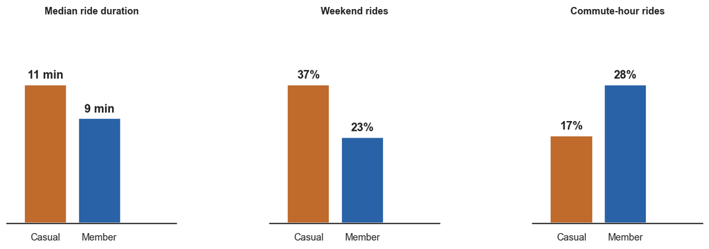

The gap is clear. Casual rides last noticeably longer than member rides — and the median (11 vs 9 minutes) actually understates it, because the casual mean is pulled much higher by long recreational rides. Members ride in commute windows notably more often (28% vs 17% of rides), and casual rides skew clearly toward weekends.

These three signals already suggest two structurally different use cases. The question I want to answer next is whether this holds for *all* casual riders, or whether some of them actually look quite similar to members once I look more closely.

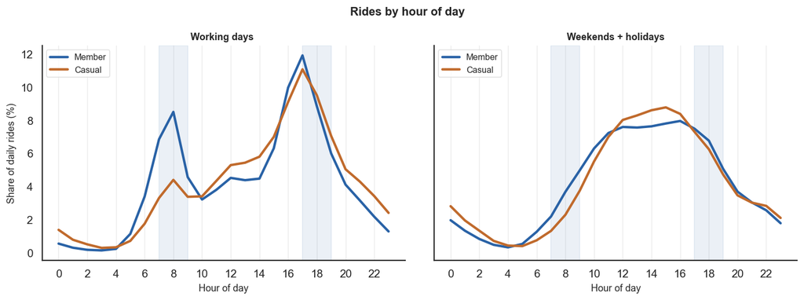

On weekends, the two groups converge. Both shift toward midday and afternoon, and the gap narrows considerably. The cleanest commute discriminator is therefore the *morning* weekday peak — that's where members stand alone.

> Each ride counts +1 at its departure hour (`started_at`) — departure patterns, not usage minutes.

## 4 · Segmentation into Subgroups

The aggregate view confirms that casual and member riders are different — but treating all casual riders as one block is too crude. A frequent evening commuter and a Sunday tourist are both labelled 'casual', yet they have almost nothing in common.

How many distinct behavioural profiles actually exist within the casual population? And what do they look like?

I use MiniBatch K-Means on 8 behavioural features to let the data answer this. K is selected empirically — inertia and silhouette scores are compared across K = 2, 3, 4.

↑ back to top

```
Casual rides for clustering: 2,010,039
Scaled feature matrix: (2010039, 8)
```

```
  K=2 | Inertia=2,050,373 | Silhouette=0.1665
```

```
  K=3 | Inertia=1,824,153 | Silhouette=0.1564
```

```
  K=4 | Inertia=1,722,843 | Silhouette=0.1339
```

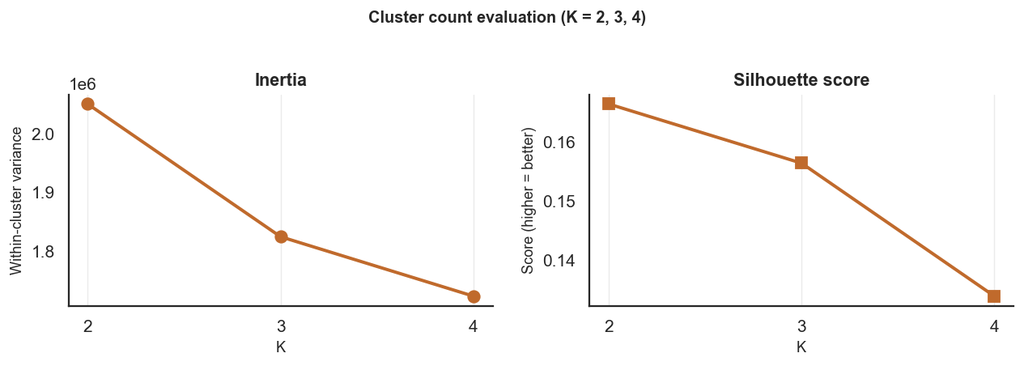

The inertia curve bends at K=3 — the drop from 2 to 3 clusters is more than twice the drop from 3 to 4. The silhouette score is technically highest at K=2, but only by a small margin, and two clusters would just split casual riders into 'weekday vs. weekend' — too coarse to act on.

So I go with K=3: the elbow supports it, the silhouette penalty is marginal, and three distinct profiles are something a marketing team can actually work with.

One honesty note: both silhouettes are modest in absolute terms, so the clusters are soft behavioural regions rather than sharply separated groups — I come back to this in the limitations.

### 4.2 Final Cluster Assignment

With K=3 confirmed, cluster labels are assigned to all casual rides. The next step is to understand what each cluster actually represents.

```
K=3 clusters assigned to 2,010,039 casual rides.

Ride counts per raw cluster:
cluster
0    856288
1    567137
2    586614
```

## 5 · Subgroup Profiles

Three clusters emerged from the data. Now the key question: *what are they?*

Each cluster is automatically named based on its two most dominant behavioural traits, detected against the thresholds below. The naming follows a fixed hierarchy — temporal context first, then bike type, then ride style — so names like "Commute Classic Riders" or "Weekend E-Bike Riders" are directly interpretable.

| Category | Trait | Threshold |
| --- | --- | --- |
| Temporal | Weekend | weekend share ≥ 65% |
| Temporal | Commute | commute share ≥ 25% AND weekend ≤ 15% |
| Temporal | Weekday | weekend share ≤ 15% (no dominant commute) |
| Bike type | E-Bike | electric share ≥ 70% |
| Bike type | Classic | electric share ≤ 25% |
| Ride style | Leisure | median duration ≥ 18 min |

Fallback name if no threshold is reached: `"Urban Riders"`.

↑ back to top

```
Cluster profiles (pre-naming):
 cluster  rides_count  avg_duration_min  avg_distance_km  weekend_share  commute_share  electric_share dominant_season
       0       856288             8.585            1.589          0.000          0.304           0.977          Summer
       1       567137            21.512            1.599          0.291          0.160           0.065          Summer
       2       586614            10.571            1.647          1.000          0.000           0.806          Summer
```

```
Cluster → Subgroup name (multi-trait system)
────────────────────────────────────────────────────────────
  Cluster 0  →  Commute E-Bike Riders
    traits  : E-Bike (0.98) | Commute (0.30)
    weekend : 0%  commute: 30%  electric: 98%  duration: 8.6 min

  Cluster 1  →  Classic Leisure Riders
    traits  : Classic (0.94) | Leisure (0.72)
    weekend : 29%  commute: 16%  electric: 6%  duration: 21.5 min

  Cluster 2  →  Weekend E-Bike Riders
    traits  : Weekend (1.00) | E-Bike (0.81)
    weekend : 100%  commute: 0%  electric: 81%  duration: 10.6 min
```

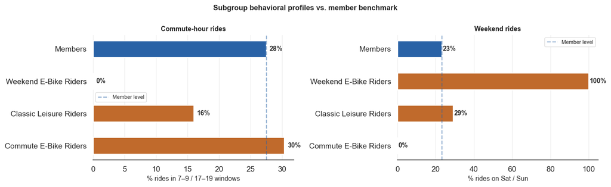

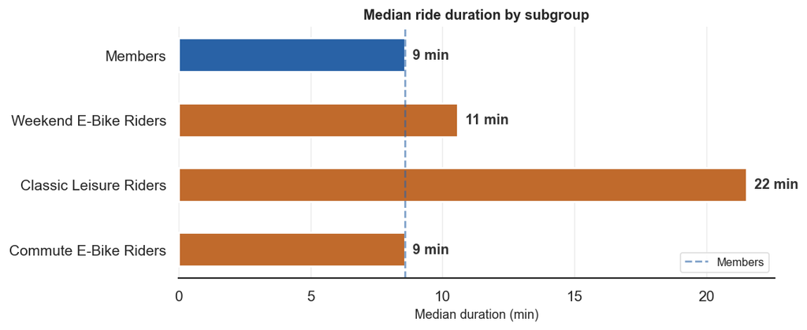

Most casual subgroups ride longer than members — but not all of them. The commute-pattern subgroup sits essentially on the member benchmark, while the leisure-oriented one is more than twice as far from it.

Short, purposeful trips are a member hallmark, so a casual subgroup that already matches that brevity is structurally more compatible with a membership model.

### Are Members Homogeneous?

Before using 'member behaviour' as a fixed reference point, I want to check: are members actually a uniform group, or do different member types exist? If the benchmark itself is fragmented, comparisons become less meaningful.

The same clustering is run on member rides to check.

↑ back to top

```
Member rides: 3,603,650
```

```
  Member K=2 | Silhouette=0.1642
```

```
  Member K=3 | Silhouette=0.1886

Selected K=3 for member segmentation (best silhouette).
Member cluster sizes:
cluster
0     553027
1    2280784
2     769839
```

```
Member subgroup names (multi-trait system)
────────────────────────────────────────────────────────────
  Cluster 0  →  E-Bike Long-Distance Members
    traits  : E-Bike (0.66) | Long-Distance (0.52)
    weekend : 12%  commute: 35%  electric: 66%  duration: 23.6 min  distance: 5.24 km

  Cluster 1  →  Commute Members
    traits  : Commute (0.35)
    weekend : 0%  commute: 35%  electric: 65%  duration: 7.1 min  distance: 1.36 km

  Cluster 2  →  Weekend Members
    traits  : Weekend (1.00)
    weekend : 100%  commute: 0%  electric: 64%  duration: 8.4 min  distance: 1.55 km
```

The member side is not monolithic either — but the structure is reassuring: the weekday member subgroups still out-commute even the most commute-oriented casual subgroup, and the largest of them does it with shorter, more purposeful trips. The gap is real, just narrower than the casual average suggests.

This tells me that closing it requires more than a promotional message; it requires reaching casual riders who already use the service in a way that resembles membership, and nudging them over the line.

### All Subgroups at a Glance

With 3 casual and 2–3 member subgroups on the board, it helps to see everything side by side. Which casual subgroup is closest to which member subgroup across duration, commute share, weekend share, and electric usage?

The table below makes that comparison immediate.

↑ back to top

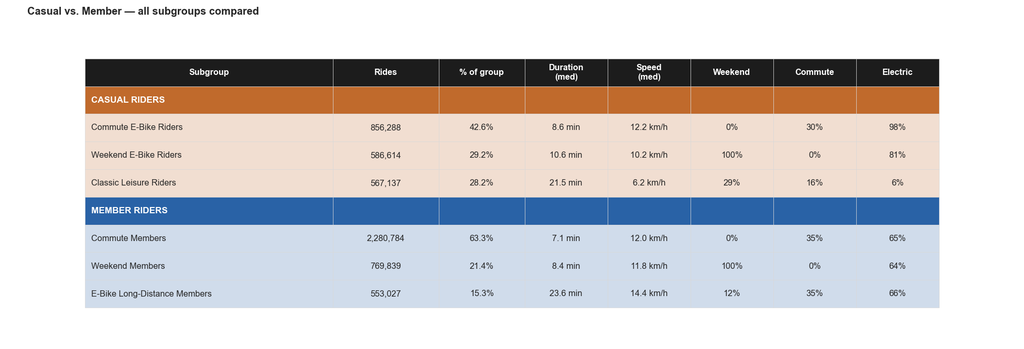

## 6 · Similarity, Volume & Conversion Priority

### 6.1 How Close Are the Casual Subgroups to Member Behaviour?

The profiles in Section 5 give a qualitative sense of which subgroup looks most like a member. Here I formalise that: each casual subgroup is scored against the overall member profile using Euclidean distance in standardised feature space.

The score runs from 0 (furthest) to 1 (closest). It's a relative ranking — 1.0 means most similar *within this set*, not identical to the member profile.

↑ back to top

```
Similarity to member profile (ranked):
                 Subgroup  Similarity  Distance
1   Commute E-Bike Riders       0.548     1.845
2   Weekend E-Bike Riders       0.152     3.463
3  Classic Leisure Riders       0.000     4.083
Note: score is relative — 1.0 = most similar in this set.
```

The ranking shows a clear spread — the three casual subgroups are not at equal distance from member behaviour. One subgroup sits meaningfully closer than the others, while one sits clearly further away.

Given that each centroid summarises hundreds of thousands of rides, this spread isn't noise: it's a structural difference with direct implications for where conversion effort is worth concentrating. One caveat — the ranking depends on the six features I chose to compare on; a different feature set could reorder the middle of the ranking.

### 6.2 How Many Rides Does Each Subgroup Generate?

Similarity is only half the story. A subgroup that looks like a member but represents just 5% of casual rides is a limited opportunity. Before ranking, I need to know the scale of each group.

> One bias to keep in mind: these are shares of **rides**, not of **people**. Frequent riders are over-represented, and a commute-like subgroup almost certainly contains the most frequent riders — so its share of distinct *users* is likely smaller than its share of rides.

↑ back to top

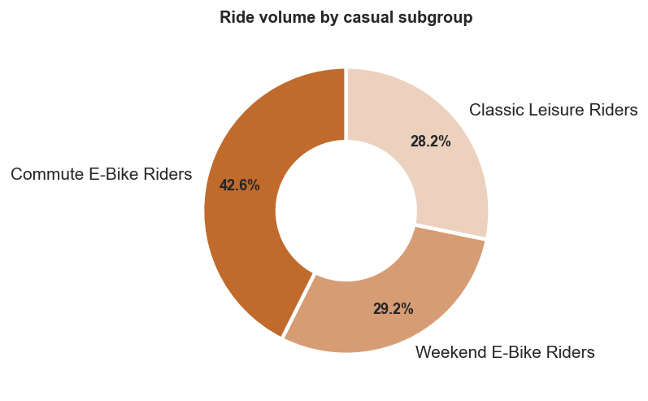

What I'm looking for here: is the largest subgroup also the most member-like, or is there a trade-off between scale and similarity? That tension is exactly what the priority score in the next section resolves.

### 6.3 Conversion Priority

Now I combine the two dimensions — similarity and ride volume — into a single priority score:

**Combined score = similarity × ride share**

A high score means the subgroup both *looks like a member* and *represents a meaningful share of casual rides* — the strongest structural conversion target. The marketing priority (High / Medium / Low) follows directly from the ranking on this score. Since ride share inherits the rides-vs-people bias from §6.2, I read the score as prioritising *observed behaviour*, not audience headcount.

↑ back to top

```
Conversion priority ranking:
              Subgroup Priority  Similarity  Ride share %  Combined score
 Commute E-Bike Riders     High       0.548        42.601           0.234
 Weekend E-Bike Riders   Medium       0.152        29.184           0.044
Classic Leisure Riders      Low       0.000        28.215           0.000
```

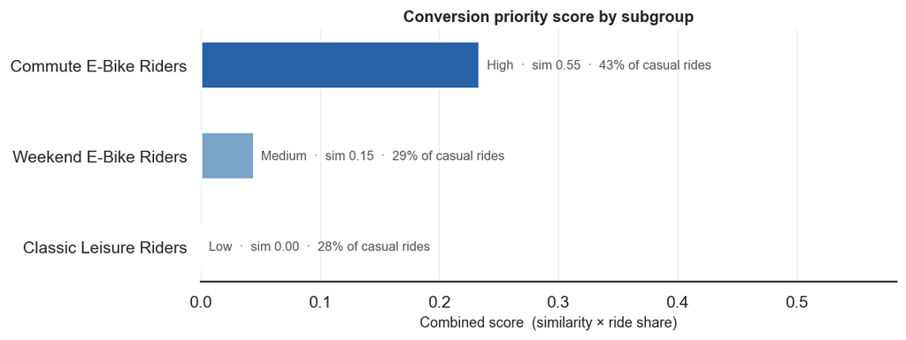

One subgroup pulls clearly ahead on the combined score — driven by a combination of meaningful similarity to members and sufficient ride volume. The others trail, not because they're irrelevant, but because the trade-off between similarity and scale is less favourable.

This is the starting point for a conversion campaign: focus resources on the high-combined-score group, explore alternative products for the rest.

### E-Bike Usage Among PM Casual Commuters

One subgroup emerged as behaviourally close to members — but there's a more specific question worth asking about the commute-adjacent casual riders: when they head home in the evening, do they prefer e-bikes? And do those rides end outside docking stations — which could signal an infrastructure gap, or simply the convenience of free-floating parking?

If both answers are yes, there's a concrete lever here beyond marketing alone.

↑ back to top

```
PM casual commuters : 245,507 rides (12.2% of casual)
E-bike share        : 68.5%  vs  67.0% (all casual)
Ends outside dock   : 26.6%  vs  24.3% (all casual)
```

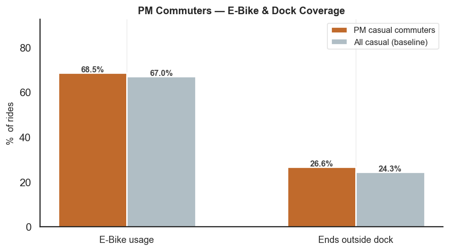

The honest reading: the differences vs. the casual average are modest — a couple of percentage points on both metrics. What matters here is the absolute level: roughly 7 out of 10 PM commute rides happen on an e-bike, and about 1 in 4 ends outside a docking station.

The dock coverage gap matters because it creates a morning problem — a rider who parks free-floating in the evening has no guarantee of finding a bike near home the next morning. Expanding docking infrastructure in the residential areas where these PM rides end could remove a real conversion barrier.

> Two caveats: 'ends outside dock' can only happen on e-bikes, so the two metrics are partly linked. And without coordinate-level spatial analysis I can't say *which specific areas* to prioritise — that would require geographic clustering of the no-dock endpoints.

## 7 · Per-Subgroup Breakdown

The aggregate scores are useful, but each subgroup has its own story. Below, each one is profiled in detail: what it looks like behaviourally, what that implies for conversion potential, and what marketing approach might work.

The summary table and the four key questions at the end collect the most actionable numbers in one place.

↑ back to top

```
SUBGROUP PROFILES — marketing view
──────────────────────────────────────────────────────────────────────────────────────────
              Subgroup   Rides  % casual  Duration (min)  % commute  % weekend  Similarity Priority
 Commute E-Bike Riders 856,288      42.6             8.6       30.4        0.0      0.5480     High
 Weekend E-Bike Riders 586,614      29.2            10.6        0.0      100.0      0.1518   Medium
Classic Leisure Riders 567,137      28.2            21.5       16.0       29.1      0.0000      Low


CASUAL vs MEMBER — direct comparison
──────────────────────────────────────────────────────────────────────
  Type                     Subgroup  Duration (min)  Speed (km/h)  % weekend  % commute
Casual        Commute E-Bike Riders             8.6          12.2        0.0       30.4
Casual       Classic Leisure Riders            21.5           6.2       29.1       16.0
Casual        Weekend E-Bike Riders            10.6          10.2      100.0        0.0
Member E-Bike Long-Distance Members            23.6          14.4       12.5       34.9
Member              Commute Members             7.1          12.0        0.0       35.0
Member              Weekend Members             8.4          11.8      100.0        0.0
```

```
── Commute E-Bike Riders  [High · 42.6% of casual · sim 0.55]
   0% weekend · 9 min · 1.59 km · 12.2 km/h · 30% commute · peak: Summer
   Weekday-only riding, 30% of departures in commute windows, short trips (9 min) — the closest casual profile to routine member use. Best structural candidate for annual membership conversion.

── Weekend E-Bike Riders  [Medium · 29.2% of casual · sim 0.15]
   100% weekend · 11 min · 1.65 km · 10.2 km/h · 0% commute · peak: Summer
   Rides concentrated on weekends (100%), short and social (11 min) — recreational use peaking in Summer. A weekend pass is a more natural offer than an annual membership.

── Classic Leisure Riders  [Low · 28.2% of casual · sim 0.00]
   29% weekend · 22 min · 1.60 km · 6.2 km/h · 16% commute · peak: Summer
   Long, slow rides (22 min at 6.2 km/h) with no dominant day pattern point to leisure and sightseeing, peaking in Summer. Better served by day or seasonal passes than by annual membership.
```

## 8 · Conclusions & Recommendations

### What I found

Casual riders are not a single group. Three distinct behavioural subgroups emerged, and they differ meaningfully in ride length, timing, and proximity to member behaviour. At least one subgroup is close enough to members that conversion targeting makes practical sense.

Volume and similarity need not align in general; in this dataset they happen to point at the same subgroup, which makes the targeting call easier than it might have been. The combined priority score keeps that balance explicit either way — with the caveat that 'volume' is measured in rides, and frequent riders are over-represented in it.

The PM commuter e-bike signal adds a concrete infrastructure dimension: dock availability in residential areas where evening rides end may matter as much as the marketing message.

### What I'd need next

1. **User IDs** — to segment by person rather than by ride
2. **Survey data** — to validate behavioural interpretations with stated intent
3. **Conversion history** — to calibrate similarity scores against real subscription outcomes

↑ back to top

```
4 Key Questions
─────────────────────────────────────────────────────────────────
Q1  Largest subgroup       : Commute E-Bike Riders (42.6% of casual rides)
    Note: volume ≠ conversion potential — read alongside similarity score.

Q2  Most member-like       : Commute E-Bike Riders (similarity 0.55)
    Note: score is relative — most similar within this set.

Q3  Best conversion target : Commute E-Bike Riders
    Note: highest combined score (similarity × ride share).

Q4  Least compatible       : Classic Leisure Riders (similarity 0.00)
    Note: low annual-membership fit ≠ no opportunity (alternative products may apply).
```

## 9 · Limitations

**Dataset constraints:**

- **No user ID** — one real user may appear in multiple subgroups depending on context.
- **~33% of rides missing station data** — GPS coordinates are used instead; station-based extensions of the analysis are not available.
- **Distance is straight-line (haversine)** — actual cycling distance is higher; speed values are approximations.

**Model constraints:**

- **Commute window is a proxy** — departure time is an assumption about trip purpose, not a direct measure of it.
- **K=3 is an interpretive choice** — optimised for business readability. K=2 or K=4 would produce different, also valid groupings.
- **Similarity score is relative** — 1.0 means most similar in this set, not identical to the member profile.
- **Ride-level shares over-represent frequent riders** — subgroup sizes, ride shares and the combined priority score count rides, not people; the commute-like subgroup is the most exposed to this inflation.
- **Cluster boundaries are soft** — silhouette scores are modest in absolute terms, and the partition leans heavily on two near-binary features (weekend flag, bike type). The subgroups are useful descriptions, not sharply separated populations.
- **Commute share has a high mechanical base rate** — the commute windows cover the busiest weekday hours, so any weekday-dominant subgroup shows a sizeable commute share by arithmetic alone (~28% for the average casual weekday ride). The 'Commute' label marks enrichment over that baseline, not proven commuting intent.

**Causal inference:**  
Behavioural similarity ≠ conversion likelihood. Price sensitivity, transport alternatives, and personal habits drive actual subscription decisions — none of which this dataset captures.

↑ back to top

## Export to HTML

[output not shown]